# Иллюстрации к статье

Вадим Хайтов

# Рисунок с датами ключевых событий

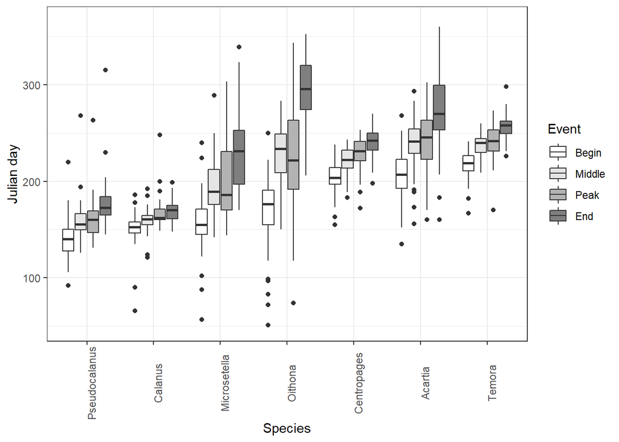

Подпись.

Боксплоты, отражающие распределения дат ключевых событий для изученных видов. Средняя линия - медиана, бокс ограничен значениями 1-st and 3-d quartiles, длина усов равна 1.5IQR (Wickham, Stryjewski, 2011), точки - “outlying” points.

# Риcунок с датами “климатических” событий

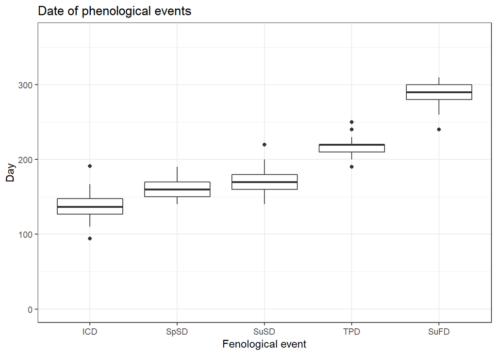

Подпись Боксплоты, отражающие распределение дат наиболее значимых гидрологических событий - ICD – Ice clear date  
- SpSD – Spring start date (the day when the water temperature overcomes 3 Celsium degrees)  
- SuSD – Summer start date (the day when the water temperature overcomes 5 Celsium degrees)  
- TPD – The date when the highest water temperaure was observed. - SuFD – The date of summer finnish

# Многолетние изменения фенологических показателей и обилия видов.

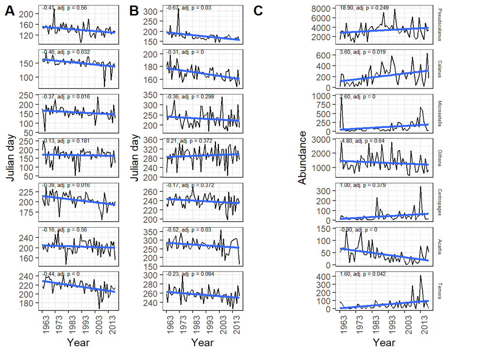

Подпись

Многолетние изменения даты начала сезона (A), даты конца сезона (B) и обилия видов копепод ($ind./m^3$) [**не уверен в том что на кубометр**]. Прямая линия - отражает линейную модель, связывающую значение, отложенное по оси ординат со временем. Числа над линией регрессии: угловой коэффициент данной модели и уровень значимости для мантеловской корреляции (детали в Материале и методах).

# Факторы, определяющие сдвиги в фенологии сообщества копепод

## Динамика показателей, включенных в анализ

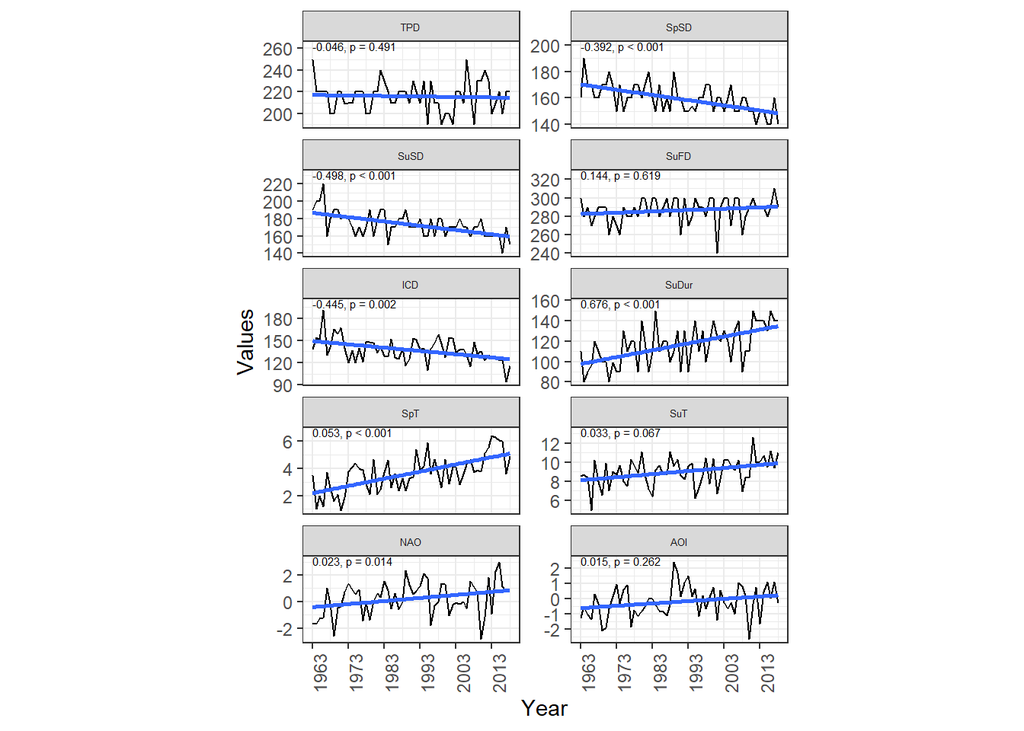

Подпись Многолетние изменения гидрологических и климатических факторов, включенных в анализ. Прямая линия - отражает линейную модель, связывающую значение, отложенное по оси ординат со временем. Числа над линией регрессии: угловой коэффициент данной модели и уровень значимости для мантеловской корреляции (детали в Материале и методах).

Обозначения

- TPD – Julian day when temperature maximum was observed
- SpSD – Julian day when hydrological spring started (water temperature reached 3 Celsium degree)
- SuSD – Julian day when hydrological summer started (water temperature reached 5 Celsium degree)
- SuFD – Julian day when hydrological summer finnished
- ICD – Julian day when ice clearing was observed
- SpT – Mean spring temperature
- SuT – Mean summer temperature
- SuDur – Summer duration (number of days)
- NAO – North Atlantic oscillation index
- AOI – Arctic oscillation index.

## Результаты ССА

**Важное изменение в методике.**

Вместо протокола “backward selection” теперь будет использован протокол “forward selection”. Это я нашел работу, где обосновывается модификация этого протокола для ССА, которую Оксанен включил в свою функцию ordistep(), а поскольку такой протокол порождает меньше сущностей и, в целом, более адаптирован для ССА, то лучше возьмем его.

Кроме того, после исправления проблем с первичкой стало немного получше с оценкой статистической значимост ССА2. Теперь можно не делать для этого анализа исключения с р=0.1.

Да, еще надо будет добавить, что в случае Oithona (6 случаев) и Microsetella (1 случай), когда прделоженный алгоритм поиска фенологических событий давал неправдоподобные результаты (дата окончания сезона превышала 365 дней, т.е. логистическая кривая не выходила на плато и не было возможности вычислить значение ассимптоты логитической кривой), эти значения рассмтаривались как пропущенные и их замещение проводилось с помощью SSA.

### Результаты

В полную модель канонического корреспондентного анализа были включены 16 гидролого-климатических предикторов, 7 величин, описывающих биотические параметры (логарифмы обилия видов в данном году), и год, как непрерывный предиктор, характеризующий линейный тренд в многолетних изменениях.

После процедуры упрощения полной модели, в финальной модели осталось лишь 3 предиктора, характеризующих гидролого-климатические условия: дата начала весны в данном году(SpSD), дата схода льда в данном году (ICD) и дата окончания лета, которая наблюдалась в прошлом году (SuFDPY) и два биотических предиктора - обилие Acartia и Microsetella.

Статистически значимых отличий полной и сокращенной модели выявлено не было ($F = $ 1.12, $p_{perm} = $, 0.221.

Table +1. Permutation significance test of the final CCA model

| term | df | ChiSquare | statistic | p.value |
| --- | --- | --- | --- | --- |
| Model | 5 | 0.0029733 | 3.070672 | 1e-04 |
| Residual | 50 | 0.0096830 | NA | NA |

Table +2. Permutation significance test of CCA constrained axis

| term | df | ChiSquare | statistic | p.value |
| --- | --- | --- | --- | --- |
| CCA1 | 1 | 0.0015219 | 7.8585931 | 0.0001 |
| CCA2 | 1 | 0.0006818 | 3.5207171 | 0.0383 |
| CCA3 | 1 | 0.0004448 | 2.2966440 | 0.1714 |
| CCA4 | 1 | 0.0002075 | 1.0715697 | 0.7107 |
| CCA5 | 1 | 0.0001173 | 0.6058361 | 0.7962 |
| Residual | 50 | 0.0096830 | NA | NA |

Table +3. Permutation significance test of each terms included in the CCA model

| term | df | ChiSquare | statistic | p.value |
| --- | --- | --- | --- | --- |
| Microsetella_N | 1 | 0.0010319 | 5.328538 | 0.0001 |
| SuFDPY | 1 | 0.0006538 | 3.375766 | 0.0017 |
| SpSD | 1 | 0.0005805 | 2.997564 | 0.0051 |
| Acartia_N | 1 | 0.0005305 | 2.739234 | 0.0090 |
| ICD | 1 | 0.0004821 | 2.489406 | 0.0169 |
| Residual | 50 | 0.0096830 | NA | NA |

Полученная финальная модель, была статистически значима (Таблица +1) и (при учете всех канонических корреспондентных осей) объясняла 23.5% of total inertia. При этом из 5 возможных канонических осей статистически значимой оказалась только первая и вторая канонические оси (Таблица +2). На эти две оси приходилось 12 и 5.4% of total inertia, соответственно. Все оставшиеся в модели предикторы имели статистическую значимость (Таблица +3).

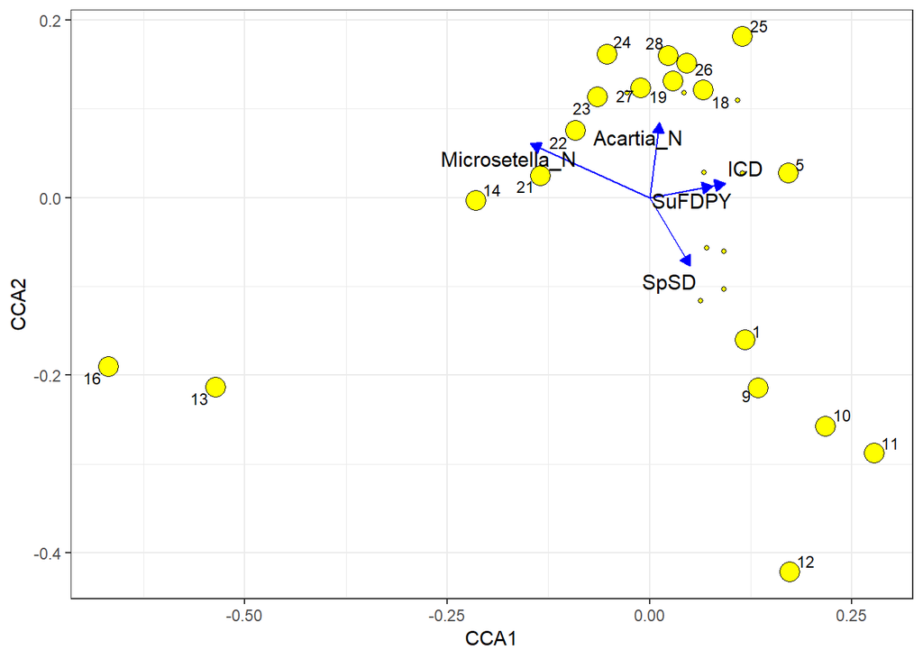

Подпись

Обозначения фенологических характеристик приведены в следующей таблице.

| Phenological Event | Label | Phenological Event | Label |
| --- | --- | --- | --- |
| Pseudocalanus_Begin | 1 | Acartia_Peak | 24 |
| Calanus_Begin | 5 | Temora_Begin | 25 |
| Microsetella_Begin | 9 | Temora_Middle | 26 |
| Microsetella_Middle | 10 | Temora_End | 27 |
| Microsetella_End | 11 | Temora_Peak | 28 |
| Microsetella_Peak | 12 | NA | NA |
| Oithona_Begin | 13 | NA | NA |
| Oithona_Middle | 14 | NA | NA |
| Oithona_Peak | 16 | NA | NA |
| Centropages_Middle | 18 | NA | NA |
| Centropages_End | 19 | NA | NA |
| Acartia_Begin | 21 | NA | NA |
| Acartia_Middle | 22 | NA | NA |
| Acartia_End | 23 | NA | NA |

На рисунке +.1 приведена ординация фенологических характеристик видов в пространстве первой и второй канонических осей. Видно, что максимальные значения по первой оси приходятся на дату пика (точка 12), дату середины (10), и дату окончания сезона (11) у Microsetella, дату начала сезона у Calanus(5). Все оставшиеся в модели гидролого-климатические факторы, положительно скоррелированы с первой канонической осью. Наиболее сильная корреляция наблюдается у даты схода льда и даты окончания лета в прошлом году. Это означает, что чем позднее происходит сход льда, чем позднее наступает весна и чем позднее закончилось лето в прошлом году, тем позднее происходят указанные выше фенологические события. (**NB означает ли более позднее окончание лета в прошлом году смещение зимы на более поздние сроки???? если да, то логично, что при этом сход льда в данном году и дата наступления весны смещаются на более поздние даты**)

Вместе с тем, есть ряд фенологических событий, которые, напротив, происходят раньше, если указанные гидролого-климатические события происходят позднее.

Так, даты начала сезона, даты середины и даты пика у Oithona (точки 13, 14, 16) и Acartia (точки 21, 22, 24), а также дата окончания сезона у Acartia (точка 23) имеют тенденцию к смещению в меньшую сторону, при увеличении значений гидролого-климатических предикторов. То есть при более позднем сходе льда, более позднем наступлении весны и более позднем окончании лета в прошлом году указанные фенологические события имеют тенденцию происходить раньше. Важно отметить, что отрицательные значения по первой канонической оси положительно коррелируют также и с обилием Microsetella. То есть в годы, когда обилие Microsetella велико, указанные фенологические показатели имеют тенденцию к смещению в большую сторону, то есть происходят позднее. Наиболее сильно эта связь проявляется в отношении фенологических характеристик у Oithona. [*в обсуждении, видимо, надо говорить о том, что это может быть следствием конкурентных отношений двух видов-оппортунистов Oithona vs Microsetella, а разная реакция на время схода льда - это разделение ниш*].

# Связь обилия вида и его фенологических показателей

**Здесь понадобится кусок в материале и методах. Пока пишу длинно, но можно и сократить.**

При анализе корреляции между временными рядами, отражающими динамику обилия популяций, с одной стороны, и динамику внешних, не зависящих от плотности, факторов, с другой стороны, могут появляться высокие корреляции даже при отсутствии значимых связей между временными рядами (Royama, 1981).

*Royama, T. (1981). Fundamental concepts and methodology for the analysis of animal population dynamics, with particular reference to univoltine species. Ecological Monographs, 51(4), 473-493.*

В связи с этим, для выявления корреляции между обилием видов и их фенологическими характеристиками (в качестве фенологического маркера была выбрана дата начала сезона пребывания вида в планктоне) был использован dichotomous nominal scale correlations method (Royama, 1981; 1992).

*Royama, T. (1992) Analytical Population Dynamics. Chapman & Hall, London.*

Вкратце суть метода сводится к следующему.

Третий этап - оценка статистической значимости полученного значения. Для оценки статистической значимости полученных коэффициентов корреляции использовался пермутационный подход (Quinn, Keough, 2002). Производились случайные перестановки значений в ряду $\{X\}$ и в ряду $\{u\}$). После каждого акта пермутации вычислялся коэффициент корреляции. Всего было проведено 9999 пермутаций. Фактически наблюдаемый коэффициент корреляции был также включен в множество коэффициентов, полученных в случайном процессе. Уровень значимости вычислялся как отношение количества коэффициентов корреляции, полученных при случайных пермутациях, больших или равных коэффициенту, полученному при сравнении фактически наблюдаемых данных, к общему количеству пермутаций плюс 1. Далее, поскольку происходило множественное тестирования гипотез (анализ связи проводился у семи видов), то производилась корректировка уровня значимости в соответствии с процедурой контроля False Discovery Rate (Benjamini, Hochberg,1995).

*Quinn, G. P., & Keough, M. J. (2002). Experimental design and data analysis for biologists. Cambridge University Press.*

## Результаты

На рисунке ++ приведены диаграммы, отражающие связь обилия вида (логарифм численности) с датой начала сезона. Оценка корреляции временных рядов, отражающих динамику обилия и динамику даты начала сезона (Таблица +4), позволяет говорить лишь о двух случаях статистически значимой связи: обилие Centropages и Temora оказывается ниже при более поздних сроках начала сезона.

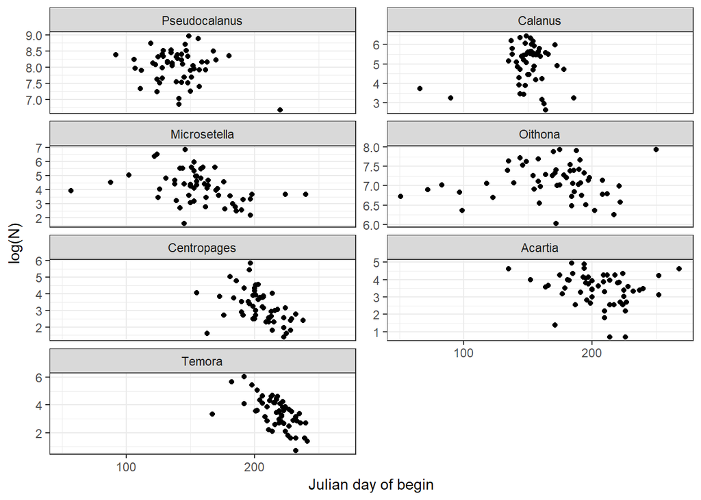

Подпись  
Связь между обилием вида в данном году и сроками начала сезона. Каждая точка соответствует отдельному году наблюдений.

Table +4. Correlation between time series reflectinging abundance and date of season begin

| Species | Correlation | Ajusted p-value |
| --- | --- | --- |
| Pseudocalanus | -0.15 | 0.8348 |
| Calanus | -0.19 | 0.8348 |
| Microsetella | -0.44 | 0.2952 |
| Oithona | -0.30 | 0.7071 |
| Centropages | -0.67 | 0.0186 |
| Acartia | -0.56 | 0.1073 |
| Temora | -0.74 | 0.0084 |